# analysis

# Load data

Variable names.

```
##  [1] "timestamp"
##  [2] "sex"
##  [3] "age"
##  [4] "residence_population"
##  [5] "not_sm_center"
##  [6] "Not hungarian"
##  [7] "no_neurologist_care"
##  [8] "sm_center_name"
##  [9] "sm_center_name_other"
## [10] "sm_center_distance"
## [11] "sm_center_distance_drop"
## [12] "sm_center_distance_changed"
## [13] "transportation_problem"
## [14] "transportation_problem_explanation"
## [15] "use_patient_transportation"
```

[output cut: 48 more lines]

Create unique ids for each participant.

# Cleaning the dataset

Deleting duplicates.

Lets see how many participants have missing data.

Data summary

| Name | processed_data |
| --- | --- |
| Number of rows | 575 |
| Number of columns | 64 |
| _______________________ |  |
| Column type frequency: |  |
| character | 54 |
| numeric | 10 |
| ________________________ |  |
| Group variables | None |

**Variable type: character**

| skim_variable | n_missing | complete_rate | min | max | empty | n_unique | whitespace |
| --- | --- | --- | --- | --- | --- | --- | --- |
| timestamp | 0 | 1.00 | 26 | 27 | 0 | 575 | 0 |
| sex | 0 | 1.00 | 2 | 5 | 0 | 2 | 0 |
| age | 0 | 1.00 | 10 | 13 | 0 | 4 | 0 |
| residence_population | 0 | 1.00 | 24 | 38 | 0 | 4 | 0 |
| sm_center_name | 0 | 1.00 | 5 | 51 | 0 | 36 | 0 |
| sm_center_name_other | 543 | 0.06 | 9 | 119 | 0 | 32 | 0 |
| sm_center_distance | 0 | 1.00 | 1 | 51 | 0 | 212 | 0 |
| transportation_problem | 0 | 1.00 | 3 | 4 | 0 | 2 | 0 |
| transportation_problem_explanation | 447 | 0.22 | 5 | 188 | 0 | 128 | 0 |
| use_patient_transportation | 0 | 1.00 | 3 | 4 | 0 | 2 | 0 |
| use_psychologist | 0 | 1.00 | 3 | 4 | 0 | 3 | 0 |
| use_psychologist_explanation | 262 | 0.54 | 7 | 280 | 0 | 287 | 0 |
| use_psychologist_code | 262 | 0.54 | 5 | 34 | 0 | 10 | 0 |
| use_physiotherapist | 0 | 1.00 | 3 | 4 | 0 | 2 | 0 |
| use_physiotherapist_explanation | 272 | 0.53 | 2 | 261 | 0 | 292 | 0 |
| use_physiotherapist_code | 274 | 0.52 | 9 | 41 | 0 | 16 | 0 |
| use_rehabilitation | 0 | 1.00 | 3 | 4 | 0 | 2 | 0 |
| use_rehabilitation_expanation | 325 | 0.43 | 1 | 240 | 0 | 232 | 0 |
| use_rehabilitation_code | 330 | 0.43 | 9 | 30 | 0 | 12 | 0 |
| walking_aid | 0 | 1.00 | 3 | 4 | 0 | 2 | 0 |
| walking_aid_financial | 0 | 1.00 | 3 | 4 | 0 | 2 | 0 |
| used_walking_aid | 0 | 1.00 | 3 | 4 | 0 | 2 | 0 |
| used_walking_aid_explanation | 322 | 0.44 | 4 | 198 | 0 | 239 | 0 |
| medical_group_membership | 0 | 1.00 | 3 | 4 | 0 | 2 | 0 |
| which_medical_group | 0 | 1.00 | 5 | 261 | 0 | 42 | 0 |
| heard_msmba | 0 | 1.00 | 3 | 4 | 0 | 2 | 0 |
| msmba_source | 144 | 0.75 | 5 | 52 | 0 | 24 | 0 |
| msmba_more_info | 357 | 0.38 | 3 | 4 | 0 | 2 | 0 |
| heard_msmba_explanation | 561 | 0.02 | 8 | 125 | 0 | 14 | 0 |
| prepare_consultation | 0 | 1.00 | 3 | 4 | 0 | 2 | 0 |
| last_mri | 9 | 0.98 | 1 | 104 | 0 | 133 | 0 |
| doctor_visit | 0 | 1.00 | 6 | 10 | 0 | 4 | 0 |
| biggest_drawback | 95 | 0.83 | 4 | 1147 | 0 | 429 | 0 |
| biggest_drawback_code | 195 | 0.66 | 5 | 18 | 0 | 19 | 0 |
| heard_manit | 0 | 1.00 | 3 | 9 | 0 | 3 | 0 |
| education_interest_order | 1 | 1.00 | 1 | 876 | 0 | 504 | 0 |
| education_interest_order_explanation | 554 | 0.04 | 1 | 1010 | 0 | 21 | 1 |
| electronic_appointment | 0 | 1.00 | 3 | 5 | 0 | 3 | 0 |
| funding | 0 | 1.00 | 3 | 5 | 0 | 3 | 0 |
| unusual_consultation_method | 0 | 1.00 | 3 | 4 | 0 | 2 | 0 |
| unusual_consultation_method_description | 358 | 0.38 | 5 | 40 | 0 | 13 | 0 |
| sm_covid_education | 0 | 1.00 | 3 | 4 | 0 | 2 | 0 |
| sm_covid_education_explanation | 279 | 0.51 | 1 | 349 | 0 | 280 | 1 |
| sm_covid_notification | 0 | 1.00 | 3 | 4 | 0 | 2 | 0 |
| sm_covid_notification_explanation | 299 | 0.48 | 1 | 230 | 0 | 273 | 0 |
| heard_tasman_education | 0 | 1.00 | 3 | 34 | 0 | 4 | 0 |
| education_preferred_method | 0 | 1.00 | 4 | 310 | 0 | 104 | 0 |
| education_preferred_method_explanation | 329 | 0.43 | 1 | 433 | 0 | 244 | 0 |
| family_understanding | 0 | 1.00 | 3 | 5 | 0 | 3 | 0 |
| person_to_help | 0 | 1.00 | 3 | 43 | 0 | 52 | 0 |
| sm_edcuation_children | 0 | 1.00 | 3 | 5 | 0 | 3 | 0 |
| relative_consultation_option | 0 | 1.00 | 3 | 4 | 0 | 2 | 0 |
| relative_consultation_need | 0 | 1.00 | 3 | 5 | 0 | 3 | 0 |
| msmba_news_explanation | 325 | 0.43 | 1 | 305 | 0 | 224 | 0 |

**Variable type: numeric**

| skim_variable | n_missing | complete_rate | mean | sd | p0 | p25 | p50 | p75 | p100 | hist |
| --- | --- | --- | --- | --- | --- | --- | --- | --- | --- | --- |
| participant_id | 0 | 1.00 | 288.73 | 166.84 | 1.0 | 144.50 | 289.00 | 432.50 | 577 | ▇▇▇▇▇ |
| not_sm_center | 564 | 0.02 | 0.91 | 0.30 | 0.0 | 1.00 | 1.00 | 1.00 | 1 | ▁▁▁▁▇ |
| Not hungarian | 567 | 0.01 | 1.00 | 0.00 | 1.0 | 1.00 | 1.00 | 1.00 | 1 | ▁▁▇▁▁ |
| no_neurologist_care | 560 | 0.03 | 1.00 | 0.00 | 1.0 | 1.00 | 1.00 | 1.00 | 1 | ▁▁▇▁▁ |
| sm_center_distance_drop | 548 | 0.05 | 1.00 | 0.00 | 1.0 | 1.00 | 1.00 | 1.00 | 1 | ▁▁▇▁▁ |
| sm_center_distance_changed | 549 | 0.05 | 25.02 | 53.65 | 1.5 | 3.25 | 6.05 | 13.75 | 250 | ▇▁▁▁▁ |
| last_mri_drop | 564 | 0.02 | 1.00 | 0.00 | 1.0 | 1.00 | 1.00 | 1.00 | 1 | ▁▁▇▁▁ |
| last_mri_changed | 434 | 0.25 | 2018.79 | 3.68 | 1999.0 | 2019.00 | 2020.00 | 2020.00 | 2021 | ▁▁▁▁▇ |
| sm_education | 1 | 1.00 | 3.58 | 1.38 | 1.0 | 3.00 | 4.00 | 5.00 | 5 | ▃▂▅▅▇ |
| msmba_news | 0 | 1.00 | 4.17 | 1.02 | 1.0 | 3.00 | 5.00 | 5.00 | 5 | ▁▁▃▃▇ |

Filling up rows with empty input values.

Deleting participants not living in Hungary.

Some respondents when asked about their SM center choose the other option and described the center in free text instead of choosing on of the pre-defined options. We replace these options with the pre-defined text so that we can analyse the SM centers prevalence.

For the MRI data we had to change the free text responses in some cases. We also decided to drop the data in some cases we will also do that now.

We would also like to extract the year of the completion of the survey.

Note, that there are cases where the last time of the MRI was later than the completition of the survey, this have to be dropped.

# EDA

N all respondent.

```
## [1] 567
```

Sex count and percentage.

```
## # A tibble: 2 × 4
##   sex       n n_all percentage
##   <chr> <int> <int>      <dbl>
## 1 férfi   121   567       21.3
## 2 nő      446   567       78.7
```

Count patients treated in not SM center.

```
## # A tibble: 2 × 4
##   not_sm_center     n n_all percentage
##           <int> <int> <int>      <dbl>
## 1             0   545   567      96.1
## 2             1    22   567       3.88
```

Plot the same.

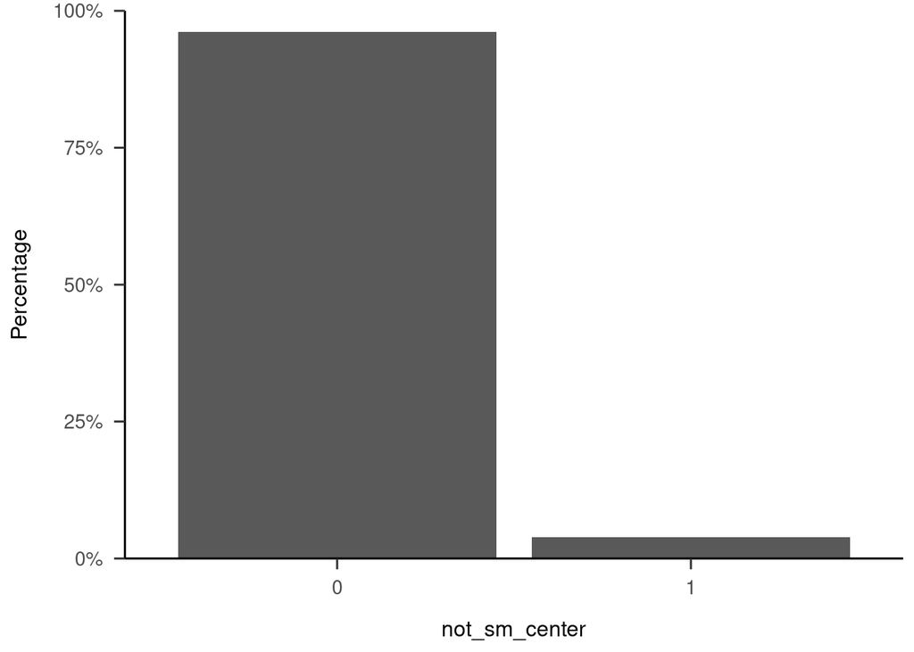

List unique SM centers in the data.

```
## # A tibble: 34 × 1
##    sm_center_name
##    <chr>
##  1 Uzsoki utcai kórház, Budapest
##  2 Csolnoky Ferenc kórház, Veszprém
##  3 BAZ Megyei Kórház, Miskolc
##  4 Semmelweis Egyetem, Budapest
##  5 Pécsi Tudományegyetem, Pécs
##  6 BKMÖ Kórház, Kecskemét
##  7 Péterfy Sándor utcai kórház, Budapest
##  8 Kaposi Mór kórház, Kaposvár
##  9 Szent Imre kórház, Budapest
## 10 Kanizsai Dorottya kórház, Nagykanizsa
## # … with 24 more rows
```

Count the number of patients treated in each SM center.

```
## # A tibble: 34 × 4
##    sm_center_name                             n n_all percentage
##    <chr>                                  <int> <int>      <dbl>
##  1 Bajcsy-Zsilinszky kórház, Budapest        13   545      2.39
##  2 BAZ Megyei Kórház, Miskolc                19   545      3.49
##  3 BKMÖ Kórház, Kecskemét                    15   545      2.75
##  4 Csolnoky Ferenc kórház, Veszprém          10   545      1.83
##  5 DEOEC Neurológiai Klinika                 39   545      7.16
##  6 Flór Ferenc Kórház, Kistarcsa              8   545      1.47
##  7 Hetényi Géza Megyei Kórház, Szolnok       12   545      2.20
##  8 Jahn Ferenc Dél-Pesti kórház, Budapest    44   545      8.07
##  9 Jósa András Kórház, Nyíregyháza           25   545      4.59
## 10 Kanizsai Dorottya kórház, Nagykanizsa      4   545      0.734
## # … with 24 more rows
```

Count how many patients do not have a neurologist.

```
## # A tibble: 2 × 4
##   no_neurologist_care     n n_all percentage
##                 <dbl> <int> <int>      <dbl>
## 1                   1    15   567       2.65
## 2                  NA   552   567      97.4
```

Age count and percentage.

```
## # A tibble: 4 × 4
##   age               n n_all percentage
##   <chr>         <int> <int>      <dbl>
## 1 16-25 éves       21   567       3.70
## 2 26-40 éves      216   567      38.1
## 3 41-59 éves      295   567      52.0
## 4 60 év feletti    35   567       6.17
```

Distance from the SM center.

```
## # A tibble: 5 × 4
##   sm_center_distance_grouped     n n_all percentage
##   <chr>                      <int> <int>      <dbl>
## 1 Between 10 and 50            257   567      45.3
## 2 Between 50 and 100            90   567      15.9
## 3 Less than 10                 151   567      26.6
## 4 More than 100                 42   567       7.41
## 5 <NA>                          27   567       4.76
```

Number of patients who do not visit neurologist.

```
## # A tibble: 2 × 2
##   no_neurologist_care     n
##                 <dbl> <int>
## 1                   1    15
## 2                  NA   552
```

Age of patients who do not visit neurologist.

```
## # A tibble: 3 × 4
##   age               n n_all percentage
##   <chr>         <int> <int>      <dbl>
## 1 26-40 éves        2    15       13.3
## 2 41-59 éves        9    15       60
## 3 60 év feletti     4    15       26.7
```

Number of patients having problem with transportation by age group.

```
## # A tibble: 8 × 5
## # Groups:   transportation_problem [2]
##   transportation_problem age               n n_all percentage
##   <chr>                  <chr>         <int> <int>      <dbl>
## 1 igen                   16-25 éves        2   123       1.63
## 2 igen                   26-40 éves       27   123      22.0
## 3 igen                   41-59 éves       87   123      70.7
## 4 igen                   60 év feletti     7   123       5.69
## 5 nem                    16-25 éves       19   444       4.28
## 6 nem                    26-40 éves      189   444      42.6
## 7 nem                    41-59 éves      208   444      46.8
## 8 nem                    60 év feletti    28   444       6.31
```

Check whether patients who have problem with transportation use the patient transportation system.

```
## # A tibble: 2 × 4
##   use_patient_transportation     n n_all percentage
##   <chr>                      <int> <int>      <dbl>
## 1 Igen                          11   123       8.94
## 2 Nem                          112   123      91.1
```

Check how often do patients meet with their doctors. Only those who are in SM centers.

```
## # A tibble: 4 × 4
##   doctor_visit     n n_all percentage
##   <chr>        <int> <int>      <dbl>
## 1 3 havonta      311   545      57.1
## 2 évente          60   545      11.0
## 3 fél évente     122   545      22.4
## 4 ritkábban       52   545       9.54
```

Lets plot the results.

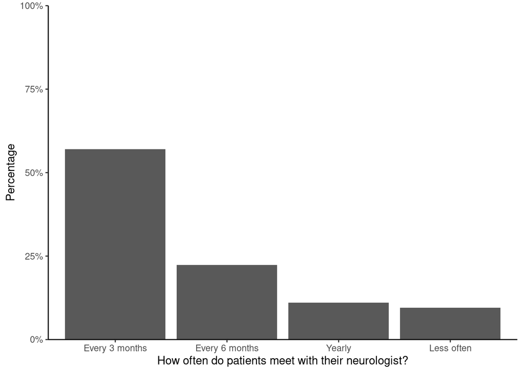

Lets see the same by age group.

```
## # A tibble: 16 × 5
## # Groups:   age [4]
##    age           doctor_visit     n n_all percentage
##    <chr>         <chr>        <int> <int>      <dbl>
##  1 16-25 éves    3 havonta       12    21      57.1
##  2 16-25 éves    fél évente       4    21      19.0
##  3 16-25 éves    ritkábban        3    21      14.3
##  4 16-25 éves    évente           2    21       9.52
##  5 26-40 éves    3 havonta      132   216      61.1
##  6 26-40 éves    fél évente      45   216      20.8
##  7 26-40 éves    évente          25   216      11.6
##  8 26-40 éves    ritkábban       14   216       6.48
##  9 41-59 éves    3 havonta      154   295      52.2
## 10 41-59 éves    fél évente      68   295      23.1
## 11 41-59 éves    ritkábban       41   295      13.9
## 12 41-59 éves    évente          32   295      10.8
## 13 60 év feletti 3 havonta       14    35      40
## 14 60 év feletti fél évente      10    35      28.6
## 15 60 év feletti ritkábban        7    35      20
## 16 60 év feletti évente           4    35      11.4
```

Lets see how many patients are part of a social organization for patients.

```
## # A tibble: 2 × 4
##   medical_group_membership     n n_all percentage
##   <chr>                    <int> <int>      <dbl>
## 1 Igen                       369   567       65.1
## 2 Nem                        198   567       34.9
```

Specifically for MSMBA.

```
## # A tibble: 2 × 4
##   heard_msmba     n n_all percentage
##   <chr>       <int> <int>      <dbl>
## 1 igen          420   567       74.1
## 2 Nem           147   567       25.9
```

Do patient who did not hear previously about MSMBA want to know more about this organization?

```
## # A tibble: 3 × 4
##   msmba_more_info     n n_all percentage
##   <chr>           <int> <int>      <dbl>
## 1 igen              128   147      87.1
## 2 Nem                14   147       9.52
## 3 <NA>                5   147       3.40
```

Specifically for MANIT.

```
## # A tibble: 3 × 4
##   heard_manit     n n_all percentage
##   <chr>       <int> <int>      <dbl>
## 1 Igen          136   567      24.0
## 2 Nem           391   567      69.0
## 3 Nem tudom      40   567       7.05
```

Lets see what do patients want to know more about.

```
## # A tibble: 13 × 5
## # Groups:   age [4]
##    age           education_interest_order                     n n_all percentage
##    <chr>         <chr>                                    <int> <int>      <dbl>
##  1 16-25 éves    SM és családtervezés                        15   141      10.6
##  2 16-25 éves    SM tünetek                                  14   141       9.93
##  3 16-25 éves    SM és munka                                 13   141       9.22
##  4 16-25 éves    SM stádiumok és progresszió                 13   141       9.22
##  5 26-40 éves    SM terápia                                 128  1557       8.22
##  6 26-40 éves    több információ tüneti gyógyszerekről (…   121  1557       7.77
##  7 26-40 éves    SM és munka                                115  1557       7.39
##  8 41-59 éves    több információ tüneti gyógyszerekről (…   191  1742      11.0
##  9 41-59 éves    SM terápia                                 151  1742       8.67
## 10 41-59 éves    védőoltásokról állásfoglalás/tájékoztató   136  1742       7.81
## 11 60 év feletti védőoltásokról állásfoglalás/tájékoztató    22   183      12.0
## 12 60 év feletti védőoltások                                 20   183      10.9
## 13 60 év feletti rehabilitáció                               16   183       8.74
```

Check whether patients prepare for consultation with their doctor.

```
## # A tibble: 2 × 4
##   prepare_consultation     n n_all percentage
##   <chr>                <int> <int>      <dbl>
## 1 igen                   224   567       39.5
## 2 Nem                    343   567       60.5
```

Lets see whether patients would be interested in getting funding for help if they had the opportunity.

```
## # A tibble: 3 × 4
##   funding     n n_all percentage
##   <chr>   <int> <int>      <dbl>
## 1 Igen      294   567       51.9
## 2 Nem        79   567       13.9
## 3 Talán     194   567       34.2
```

Check whether patients use aid for walking.

```
## # A tibble: 2 × 4
##   walking_aid     n n_all percentage
##   <chr>       <int> <int>      <dbl>
## 1 Igen          176   567       31.0
## 2 Nem           391   567       69.0
```

Same for age group.

```
## # A tibble: 8 × 5
## # Groups:   age [4]
##   age           walking_aid     n n_all percentage
##   <chr>         <chr>       <int> <int>      <dbl>
## 1 16-25 éves    Nem            20    21      95.2
## 2 16-25 éves    Igen            1    21       4.76
## 3 26-40 éves    Nem           180   216      83.3
## 4 26-40 éves    Igen           36   216      16.7
## 5 41-59 éves    Nem           179   295      60.7
## 6 41-59 éves    Igen          116   295      39.3
## 7 60 év feletti Igen           23    35      65.7
## 8 60 év feletti Nem            12    35      34.3
```

Lets see if those who use a walking aid ever had financial problems in getting one.

```
## # A tibble: 2 × 4
##   walking_aid_financial     n n_all percentage
##   <chr>                 <int> <int>      <dbl>
## 1 igen                     45   176       25.6
## 2 Nem                     131   176       74.4
```

Lets see if they would be willing to buy walking aid.

```
## # A tibble: 2 × 4
##   used_walking_aid     n n_all percentage
##   <chr>            <int> <int>      <dbl>
## 1 Igen               272   567       48.0
## 2 Nem                295   567       52.0
```

If they are a member in a social helping which group is it? Because it was a multiple choice question with a lot of categories it is not easy to present the results in an understandable format.

There were 369 participants who are part of any medical community groups. Out of these how many are part of at least one type of Hungarian FB group?

```
## [1] 313
```

How many of them are the part of MSMBA? As this was a multiple choice question there can be an overlap. It is possible to calculate the overlap but I do not think it is relevant.

```
## [1] 114
```

Are they interested in further education regarding MS?

```
## # A tibble: 6 × 4
##   sm_education     n n_all percentage
##          <dbl> <int> <int>      <dbl>
## 1            1    72   567     12.7
## 2            2    49   567      8.64
## 3            3   134   567     23.6
## 4            4   110   567     19.4
## 5            5   201   567     35.4
## 6           NA     1   567      0.176
```

Same per age group.

```
## # A tibble: 21 × 5
## # Groups:   age [4]
##    age        sm_education     n n_all percentage
##    <chr>             <dbl> <int> <int>      <dbl>
##  1 16-25 éves            1     2    21       9.52
##  2 16-25 éves            2     1    21       4.76
##  3 16-25 éves            3     5    21      23.8
##  4 16-25 éves            4     3    21      14.3
##  5 16-25 éves            5    10    21      47.6
##  6 26-40 éves            1    22   216      10.2
##  7 26-40 éves            2    14   216       6.48
##  8 26-40 éves            3    41   216      19.0
##  9 26-40 éves            4    47   216      21.8
## 10 26-40 éves            5    92   216      42.6
## # … with 11 more rows
```

Did they use any other method for consultation then phone or meeting in person?

```
## # A tibble: 2 × 4
##   unusual_consultation_method     n n_all percentage
##   <chr>                       <int> <int>      <dbl>
## 1 igen                          204   567       36.0
## 2 nem                           363   567       64.0
```

Same per age group.

```
## # A tibble: 8 × 5
## # Groups:   age [4]
##   age           unusual_consultation_method     n n_all percentage
##   <chr>         <chr>                       <int> <int>      <dbl>
## 1 16-25 éves    nem                            14    21       66.7
## 2 16-25 éves    igen                            7    21       33.3
## 3 26-40 éves    nem                           129   216       59.7
## 4 26-40 éves    igen                           87   216       40.3
## 5 41-59 éves    nem                           198   295       67.1
## 6 41-59 éves    igen                           97   295       32.9
## 7 60 év feletti nem                            22    35       62.9
## 8 60 év feletti igen                           13    35       37.1
```

Which method did they use if they answered yes.

```
## # A tibble: 6 × 4
##   unusual_consultation_method_description     n n_all percentage
##   <chr>                                   <int> <int>      <dbl>
## 1 egyéb                                      11   249       4.42
## 2 email                                     155   249      62.2
## 3 facebook messenger                         62   249      24.9
## 4 skype                                       3   249       1.20
## 5 viber                                      10   249       4.02
## 6 <NA>                                        8   249       3.21
```

Same for age group.

```
## # A tibble: 13 × 5
## # Groups:   age [4]
##    age           unusual_consultation_method_description     n n_all percentage
##    <chr>         <chr>                                   <int> <int>      <dbl>
##  1 16-25 éves    email                                       6    10      60
##  2 16-25 éves    facebook messenger                          3    10      30
##  3 16-25 éves    egyéb                                       1    10      10
##  4 26-40 éves    email                                      67   107      62.6
##  5 26-40 éves    facebook messenger                         27   107      25.2
##  6 26-40 éves    viber                                       6   107       5.61
##  7 41-59 éves    email                                      72   113      63.7
##  8 41-59 éves    facebook messenger                         25   113      22.1
##  9 41-59 éves    egyéb                                       7   113       6.19
## 10 60 év feletti email                                      10    19      52.6
## 11 60 év feletti facebook messenger                          7    19      36.8
## 12 60 év feletti egyéb                                       1    19       5.26
## 13 60 év feletti skype                                       1    19       5.26
```

Which further education method is prefered?

```
## # A tibble: 10 × 4
##    education_preferred_method                                 n n_all percentage
##    <chr>                                                  <int> <int>      <dbl>
##  1 egyéb                                                     41  1086       3.78
##  2 mind                                                      43  1086       3.96
##  3 online: zoom, skype vagy teams platformon                234  1086      21.5
##  4 személyes: betegszervezet által szervezetten              69  1086       6.35
##  5 személyes: kis csoportos max. 10-12 fő részvételével …   110  1086      10.1
##  6 személyes: SM centrumokban                               118  1086      10.9
##  7 személyesen: SM Café formájában egy cukrászdában vagy…    59  1086       5.43
##  8 videóelőadás tár                                         128  1086      11.8
##  9 webinar                                                   74  1086       6.81
## 10 youtube csatorna                                         210  1086      19.3
```

Same for age group.

```
## # A tibble: 14 × 5
## # Groups:   age [4]
##    age           education_preferred_method                   n n_all percentage
##    <chr>         <chr>                                    <int> <int>      <dbl>
##  1 16-25 éves    online: zoom, skype vagy teams platform…     8    38       21.1
##  2 16-25 éves    youtube csatorna                             7    38       18.4
##  3 16-25 éves    személyes: kis csoportos max. 10-12 fő …     6    38       15.8
##  4 16-25 éves    személyes: SM centrumokban                   6    38       15.8
##  5 26-40 éves    online: zoom, skype vagy teams platform…   104   464       22.4
##  6 26-40 éves    youtube csatorna                            96   464       20.7
##  7 26-40 éves    videóelőadás tár                            53   464       11.4
##  8 41-59 éves    online: zoom, skype vagy teams platform…   111   518       21.4
##  9 41-59 éves    youtube csatorna                           100   518       19.3
## 10 41-59 éves    videóelőadás tár                            64   518       12.4
## 11 60 év feletti online: zoom, skype vagy teams platform…    11    66       16.7
## 12 60 év feletti személyes: kis csoportos max. 10-12 fő …    10    66       15.2
## 13 60 év feletti személyes: SM centrumokban                  10    66       15.2
## 14 60 év feletti videóelőadás tár                            10    66       15.2
```

Do they feel that their family understands their illness?

```
## # A tibble: 3 × 4
##   family_understanding     n n_all percentage
##   <chr>                <int> <int>      <dbl>
## 1 Igen                   344   567      60.7
## 2 Nem                     56   567       9.88
## 3 Talán                  167   567      29.5
```

Who can they depend on?

```
## # A tibble: 6 × 4
##   person_to_help     n n_all percentage
##   <chr>          <int> <int>      <dbl>
## 1 anya             281  1264      22.2
## 2 apa              166  1264      13.1
## 3 barátok          233  1264      18.4
## 4 egyéb            321  1264      25.4
## 5 gyermekek        210  1264      16.6
## 6 szomszédok        53  1264       4.19
```

Same for age group.

```
## # A tibble: 12 × 5
## # Groups:   age [4]
##    age           person_to_help     n n_all percentage
##    <chr>         <chr>          <int> <int>      <dbl>
##  1 16-25 éves    anya              16    52       30.8
##  2 16-25 éves    apa               13    52       25
##  3 16-25 éves    barátok           12    52       23.1
##  4 26-40 éves    anya             153   535       28.6
##  5 26-40 éves    egyéb            133   535       24.9
##  6 26-40 éves    barátok          102   535       19.1
##  7 41-59 éves    egyéb            161   618       26.1
##  8 41-59 éves    gyermekek        146   618       23.6
##  9 41-59 éves    barátok          109   618       17.6
## 10 60 év feletti gyermekek         24    59       40.7
## 11 60 év feletti egyéb             17    59       28.8
## 12 60 év feletti barátok           10    59       16.9
```

Would they participate in MS education programs WITH their family?

```
## # A tibble: 3 × 4
##   sm_edcuation_children     n n_all percentage
##   <chr>                 <int> <int>      <dbl>
## 1 Igen                    169   567       29.8
## 2 Nem                     186   567       32.8
## 3 Talán                   212   567       37.4
```

Is it possible for relatives to join the consultation with the doctor?

```
## # A tibble: 2 × 4
##   relative_consultation_option     n n_all percentage
##   <chr>                        <int> <int>      <dbl>
## 1 Igen                           385   567       67.9
## 2 Nem                            182   567       32.1
```

Do they want relatives to join?

```
## # A tibble: 3 × 4
##   relative_consultation_need     n n_all percentage
##   <chr>                      <int> <int>      <dbl>
## 1 Igen                         215   567       37.9
## 2 Nem                          156   567       27.5
## 3 Talán                        196   567       34.6
```

Would they be willing to go to psychologist?

```
## # A tibble: 3 × 4
##   use_psychologist     n n_all percentage
##   <chr>            <int> <int>      <dbl>
## 1 igen                 1   567      0.176
## 2 Igen               116   567     20.5
## 3 Nem                450   567     79.4
```

Same per age group.

```
## # A tibble: 9 × 5
## # Groups:   age [4]
##   age           use_psychologist     n n_all percentage
##   <chr>         <chr>            <int> <int>      <dbl>
## 1 16-25 éves    Nem                 19    21     90.5
## 2 16-25 éves    Igen                 2    21      9.52
## 3 26-40 éves    Nem                169   216     78.2
## 4 26-40 éves    Igen                47   216     21.8
## 5 41-59 éves    Nem                229   295     77.6
## 6 41-59 éves    Igen                65   295     22.0
## 7 41-59 éves    igen                 1   295      0.339
## 8 60 év feletti Nem                 33    35     94.3
## 9 60 év feletti Igen                 2    35      5.71
```

What are the main reasons behind NOT wanting to go to psychologist?

```
## # A tibble: 8 × 4
##   use_psychologist_code                  n n_all percentage
##   <chr>                              <int> <int>      <dbl>
## 1 <NA>                                 239   450     53.1
## 2 nincs szüksége rá                    131   450     29.1
## 3 nem értelmezhető                      30   450      6.67
## 4 nem hisz benne                        17   450      3.78
## 5 nem elérhető a szolgáltatás           16   450      3.56
## 6 nincs pénze rá                        13   450      2.89
## 7 nincs bátorsága hozzá                  3   450      0.667
## 8 a rokkantság miatt nem tud elmenni     1   450      0.222
```

Main reasons behind wanting to go to a psychologist?

```
## # A tibble: 7 × 4
##   use_psychologist_code            n n_all percentage
##   <chr>                        <int> <int>      <dbl>
## 1 egyéb                           34   117     29.1
## 2 szorongás, depresszió, pánik    24   117     20.5
## 3 betegség feldolgozása           23   117     19.7
## 4 <NA>                            20   117     17.1
## 5 nem értelmezhető                14   117     12.0
## 6 nem elérhető a szolgáltatás      1   117      0.855
## 7 nincs pénze rá                   1   117      0.855
```

Do patients ask for hep from a physiotherapist?

```
## # A tibble: 2 × 4
##   use_physiotherapist     n n_all percentage
##   <chr>               <int> <int>      <dbl>
## 1 igen                  164   567       28.9
## 2 Nem                   403   567       71.1
```

What are the main reasons behind NOT asking for help?

```
## # A tibble: 12 × 4
##    use_physiotherapist_code                      n n_all percentage
##    <chr>                                     <int> <int>      <dbl>
##  1 <NA>                                        228   403     56.6
##  2 nincs szüksége rá                           101   403     25.1
##  3 nem elérhető a szolgáltatás                  33   403      8.19
##  4 nem értelmezhető                             16   403      3.97
##  5 nincs pénze rá                               10   403      2.48
##  6 nem kapott tájékoztatást, hogy jó lehetne     5   403      1.24
##  7 nem segít                                     5   403      1.24
##  8 nem elérhető a foglalkozás                    1   403      0.248
##  9 nem kapott tájékoztatást, hogy jó lehet       1   403      0.248
## 10 nincs szükségem rá                            1   403      0.248
## 11 nincs szüskége rá                             1   403      0.248
## 12 szüksége van rá                               1   403      0.248
```

Do they use rehabilitation?

```
## # A tibble: 2 × 4
##   use_rehabilitation     n n_all percentage
##   <chr>              <int> <int>      <dbl>
## 1 Igen                  93   567       16.4
## 2 Nem                  474   567       83.6
```

What are the main reasons behind not using rehabilitation?

```
## # A tibble: 9 × 4
##   use_rehabilitation_code         n n_all percentage
##   <chr>                       <int> <int>      <dbl>
## 1 <NA>                          298   474     62.9
## 2 nincs szüksége rá              79   474     16.7
## 3 nem értelmezhető               31   474      6.54
## 4 nem ajánlották                 18   474      3.80
## 5 nem elérhető a szolgáltatás    18   474      3.80
## 6 nem tudja mit jelent           16   474      3.38
## 7 nem segít                      11   474      2.32
## 8 nincs pénze rá                  2   474      0.422
## 9 nem elérheő a szolgáltatás      1   474      0.211
```

What are the most serious symptoms reported by the patients?

```
## # A tibble: 19 × 4
##    biggest_drawback_code     n n_all percentage
##    <chr>                 <int> <int>      <dbl>
##  1 <NA>                    192   567     33.9
##  2 mobilitás               121   567     21.3
##  3 fáradékonyság            67   567     11.8
##  4 bizonytalanság           28   567      4.94
##  5 egyensúlyzavar           25   567      4.41
##  6 pszichés                 19   567      3.35
##  7 elfogadás                18   567      3.17
##  8 NINCS                    17   567      3.00
##  9 fájdalom                 15   567      2.65
## 10 vegetatív zavar          15   567      2.65
## 11 kognitív zavar           13   567      2.29
## 12 nincs munkája             9   567      1.59
## 13 progresszió               9   567      1.59
## 14 izomgörcsök               6   567      1.06
## 15 zsibbadás                 5   567      0.882
## 16 látás                     3   567      0.529
## 17 izoláció                  2   567      0.353
## 18 relapszus                 2   567      0.353
## 19 kiszolgáltatottság        1   567      0.176
```

Do people who has bizonytalanság, pszichés, elfogadás, kognitív zavar as the biggest symptom go to psychological therapy?

```
## # A tibble: 4 × 5
## # Groups:   symptom_type [2]
##   symptom_type           use_psychologist     n n_all percentage
##   <chr>                  <chr>            <int> <int>      <dbl>
## 1 Other symptoms         igen               100   489       20.4
## 2 Other symptoms         nem                389   489       79.6
## 3 Psychological symptoms igen                17    78       21.8
## 4 Psychological symptoms nem                 61    78       78.2
```

The proportion of patients with psychological symptomps.

```
## # A tibble: 2 × 4
##   symptom_type               n n_all percentage
##   <chr>                  <int> <int>      <dbl>
## 1 Other symptoms           489   567       86.2
## 2 Psychological symptoms    78   567       13.8
```

Why do patients with psychological symptoms do not go to psychologist?

```
## # A tibble: 6 × 4
##   use_psychologist_code           n n_all percentage
##   <chr>                       <int> <int>      <dbl>
## 1 nem elérhető a szolgáltatás     3    61       4.92
## 2 nem értelmezhető                3    61       4.92
## 3 nincs bátorsága hozzá           2    61       3.28
## 4 nincs pénze rá                  2    61       3.28
## 5 nincs szüksége rá              22    61      36.1
## 6 <NA>                           29    61      47.5
```

Same with plot.

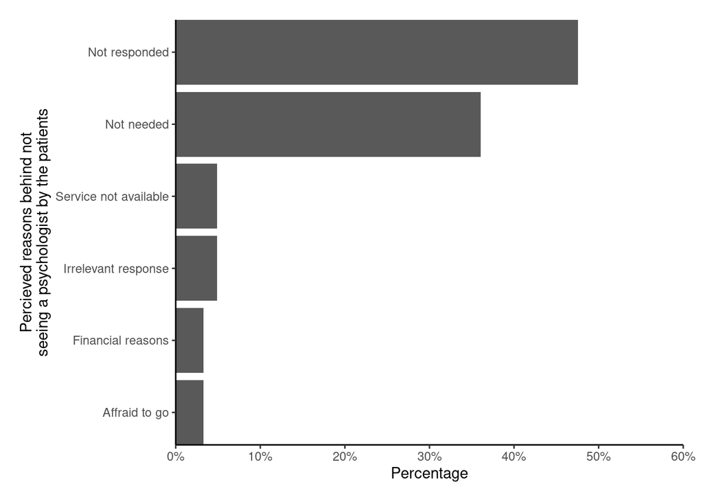

How big proportion of those who have mobilitás, fáradékonyság, egyensúlyzavar, fájdalom as main symptom goes to physical therapy?

```
## # A tibble: 4 × 5
## # Groups:   symptom_type [2]
##   symptom_type           use_physiotherapist     n n_all percentage
##   <chr>                  <chr>               <int> <int>      <dbl>
## 1 Other symptoms         igen                   88   339       26.0
## 2 Other symptoms         nem                   251   339       74.0
## 3 Physiological symptoms igen                   76   228       33.3
## 4 Physiological symptoms nem                   152   228       66.7
```

The same on a plot.

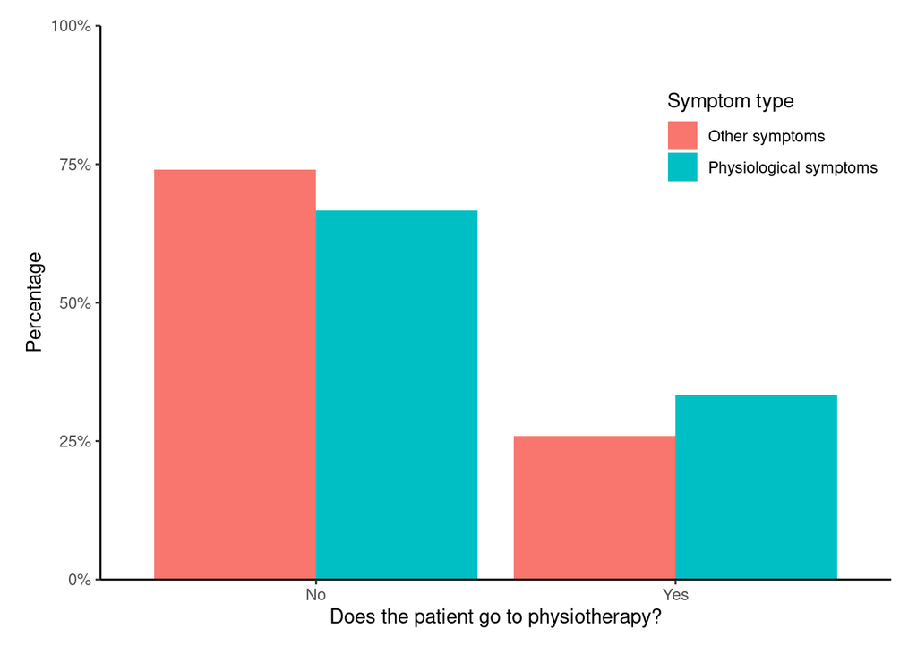

Do they go to rehabilitation?

```
## # A tibble: 4 × 5
## # Groups:   symptom_type [2]
##   symptom_type           use_rehabilitation     n n_all percentage
##   <chr>                  <chr>              <int> <int>      <dbl>
## 1 Other symptoms         igen                  48   339       14.2
## 2 Other symptoms         nem                  291   339       85.8
## 3 Physiological symptoms igen                  45   228       19.7
## 4 Physiological symptoms nem                  183   228       80.3
```

Do patients with mobilitás, egyensúlyzavar problems use walking aids?

```
## # A tibble: 4 × 5
## # Groups:   symptom_type [2]
##   symptom_type           walking_aid     n n_all percentage
##   <chr>                  <chr>       <int> <int>      <dbl>
## 1 Other symptoms         igen           88   421       20.9
## 2 Other symptoms         nem           333   421       79.1
## 3 Physiological symptoms igen           88   146       60.3
## 4 Physiological symptoms nem            58   146       39.7
```

Educational interest.

```
## # A tibble: 23 × 4
##    education_interest_order                        n n_patients percentage_pati…
##    <chr>                                       <int>      <int>            <dbl>
##  1 több információ tüneti gyógyszerekről (pl.…   333        560             59.5
##  2 SM terápia                                    306        560             54.6
##  3 védőoltásokról állásfoglalás/tájékoztató      267        560             47.7
##  4 védőoltások                                   258        560             46.1
##  5 SM és munka                                   240        560             42.9
##  6 gyógytorna                                    227        560             40.5
##  7 SM stádiumok és progresszió                   225        560             40.2
##  8 szociális ellátás, rokkantnyugdíj, egyéb t…   211        560             37.7
##  9 rehabilitáció                                 172        560             30.7
## 10 oktató videók a betegszervezet (MSMBA) és/…   123        560             22.0
## # … with 13 more rows
```

How many patients had an MRI lately?

```
## # A tibble: 20 × 4
##    last_mri_time     n n_all percentage
##            <int> <int> <int>      <dbl>
##  1             0   161   528     30.5
##  2             1   189   528     35.8
##  3             2    91   528     17.2
##  4             3    24   528      4.55
##  5             4    14   528      2.65
##  6             5    14   528      2.65
##  7             6     5   528      0.947
##  8             7     4   528      0.758
##  9             8     7   528      1.33
## 10             9     3   528      0.568
## 11            10     1   528      0.189
## 12            11     6   528      1.14
## 13            12     1   528      0.189
## 14            13     1   528      0.189
## 15            15     1   528      0.189
## 16            17     1   528      0.189
## 17            21     1   528      0.189
## 18            22     2   528      0.379
## 19            24     1   528      0.189
## 20            29     1   528      0.189
```